# Extracting information from PHE blogs and publications

Julian Flowers

2018-07-24

PHE publishes a range of information to https://www.gov.uk/phe inlcuding blogs, statistics and other publications.

This vignette introduces an internal PHE R package `myScrapers` which includes tools to extract published public health information from:

- NHS Digital
- NICE Public Health Guidance
- .GOV.UK

These tools are intended to help text mining and analysis of published content, to assist developing outputs such as products and services catalogues, and to make it easier to identify public health content at NHS Digital.

The functions are assembled as an R package which is currently available on github at https://github.com/julianflowers/myScrapers.

## Getting started

The first step is to install the package. This can be achieved with the code below:

```r
library(devtools)
library(pacman)
if(!require("myScrapers"))install_github("julianflowers/myScrapers", build_vignettes =TRUE)

p_load(myScrapers, tidyverse, tidytext, quanteda, Rcrawler)
```

# Get a list of Directors of Public Health

This is easily achieved with the `get_dsph_england()` function.

```r
dsph <- get_dsph_england()

head(dsph)
```

```
#>                 LA          Name
#> 1         Derby UA   Cate Edwynn
#> 2       Derbyshire  Dean Wallace
#> 3     Leicester UA  Ruth Tennant
#> 4   Leicestershire   Mike Sandys
#> 5     Lincolnshire    Derek Ward
#> 6 Northamptonshire Lucy Wightman
```

# PHE Blogs

The URL for PHE blogs is “https://publichealthmatters.blog.gov.uk”.

We can obtain a table of blog topic categories or authors…

```r
url <- "https://publichealthmatters.blog.gov.uk"
url1 <- paste0(url,  "/page/", 2:73)
urls <- c(url, url1)

cats <- get_blog_categories(urls)

cats
```

```
#>  [1] "duncan-selbie-friday-message"  "hwb"
#>  [3] "hp"                            "phes-science"
#>  [5] "priority2"                     "local-authority-public-health"
#>  [7] "health-improvement"            "health-matters"
#>  [9] "health-and-work"               "disease-detectives"
#> [11] "data-blog"                     "digital"
#> [13] "uncategorized"                 "cko"
#> [15] "science-hub"                   "london-region"
#> [17] "priority3"                     "global-health"
#> [19] "northern-region"               "health-profile-for-england"
#> [21] "priority5"                     "phe-announcement"
#> [23] "phe-people"                    "health-in-a-changing-climate"
#> [25] "health-visitors"               "the-week-at-phe"
#> [27] "priority6"                     "nursing"
#> [29] "priority4"                     "midlands-and-east-of-england"
#> [31] "midwifery"                     "priority1"
#> [33] "priority7"                     "microbiology-services"
#> [35] "mythbuster"                    "ab"
```

```r
url <- "https://publichealthmatters.blog.gov.uk"

authors <- get_blog_authors(url)

authors
```

```
#>   [1] "duncan-selbie"                 "kate-folkard"
#>   [3] "dominik-zenner"                "binta-hanakuka"
#>   [5] "brian-ferguson"                "peter-kelly"
#>   [7] "local-authority-public-health" "martin-dockrell"
#>   [9] "ann-marie-connolly"            "jane-south"
#>  [11] "carla-brown"                   "catherine-hayes"
#>  [13] "eamonn-omoore"                 "jo-peden"
#>  [15] "justin-varney"                 "alison-tedstone"
#>  [17] "martin-ward-platt"             "jude-stansfield"
#>  [19] "mary-bythell"                  "jamie-waterall"
#>  [21] "jennifer-lloyd"                "leoni-belsman"
#>  [23] "rosanna-oconnor"               "dave-jephson"
#>  [25] "justine-fitzpatrick"           "clare-griffiths"
#>  [27] "eustace-de-sousa"              "claire-robson"
#>  [29] "emma-seria-walker"             "linda-hindle"
```

[output cut: 91 more lines]

## Blog text

We can extract blog posts for any given category e.g. *the-week-at-phe*

```r
n <- 6
url <- "https://publichealthmatters.blog.gov.uk/category/the-week-at-phe/"
url1 <- paste0(url, "/page/", 2:n)
ifelse( n>1, urls <- c(url, url1), urls <- url)
```

```
#> [1] "https://publichealthmatters.blog.gov.uk/category/the-week-at-phe/"
```

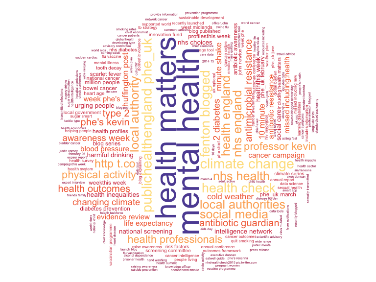

```r
#cat <- "local-authority-public-health/"
links <- map(urls, function(x) get_blog_links(x))
links1 <-  flatten(links) %>% unique() %>% map_chr(1)
links1 <- links1[-11]
blogs <- map(links1, function(x) get_blog_text(x))
 blogs1 <- map(blogs, data.frame)
 blogs2 <- map_df(blogs1, bind_rows)
colnames(blogs2) <- c("text", "url")


palette <- RColorBrewer::brewer.pal(10, rev("Spectral"))

blogs2 %>%
  create_bigrams(text) %>%
  group_by(bigram) %>%
  count(sort=TRUE) %>%
  filter(!bigram %in% c("public health", "we’re pleased", "past week", "phe’s online", "week here’s", "online activity", "kevin fenton", "friday messages", "wishes friday")) %>%
  with(., wordcloud::wordcloud(bigram, n, colors = palette, random.order = FALSE, random.color = FALSE, max.words = "Inf", rot.per = 0.4, scale = c(4, 0.1)))
```

or Duncan’s friday message

```r
n <- 7
url <- "https://publichealthmatters.blog.gov.uk/category/duncan-selbie-friday-message/"
url1 <- paste0(url, "/page/", 2:n)
ifelse( n>1, urls <- c(url, url1), urls <- url)
```

```
#> [1] "https://publichealthmatters.blog.gov.uk/category/duncan-selbie-friday-message/"
```

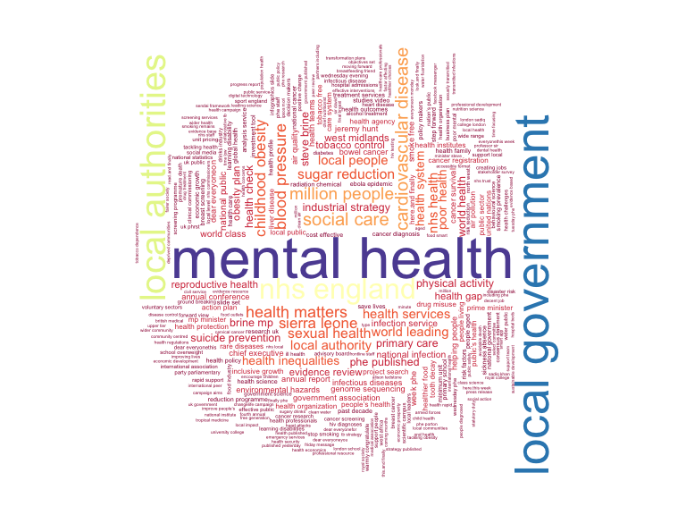

```r
#cat <- "local-authority-public-health/"
links <- map(urls, function(x) get_blog_links(x))
links1 <-  flatten(links) %>% unique() %>% map_chr(1)
links1 <- links1[-11]
blogs_ds <- map(links1, function(x) get_blog_text(x))
blogs_ds1 <- map(blogs_ds, data.frame)
blogs_ds2 <- map_df(blogs_ds1, bind_rows)
colnames(blogs_ds2) <- c("text", "url")


palette <- RColorBrewer::brewer.pal(11, "Spectral")

blogs_ds2 %>%
  create_bigrams(text) %>%
  group_by(bigram) %>%
  count(sort=TRUE) %>%
  ungroup() %>%
  mutate(bigram = tm::removeNumbers(bigram)) %>%
  filter(!bigram %in% c("public health", "we’re pleased", "past week", "phe’s online", "week here’s", "online activity", "friday messages", "wishes friday")) %>%
  with(., wordcloud::wordcloud(bigram, n, colors = palette, random.order = FALSE, random.color = FALSE, max.words = "Inf", rot.per = 0.4, scale = c(4, 0.1)))
```

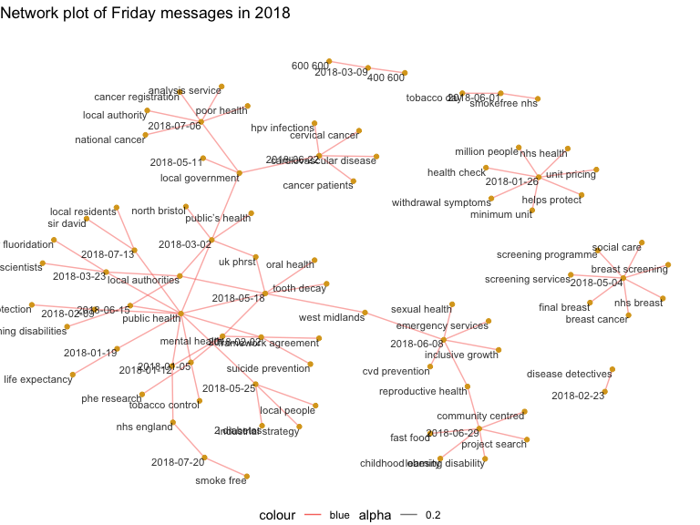

```r
library(igraph)
library(ggraph)

bigrams <- create_bigrams(blogs_ds2, text)

bigrams <- bigrams %>%
  separate(url, remove = FALSE, c("root", "name", "cat", "message",  "day", "month", "year" ), sep = "-") %>%
  mutate(year = str_replace_all(year, "/", "")) %>%
  unite(date, day, month, year, sep ="-") %>%
  select(date, bigram, n)

big_count <- bigrams %>%
  mutate(date = str_replace_all(date, "/-NA", "-2017"),
    date1 = lubridate::dmy(date)) %>%
  group_by(date, date1, bigram) %>%
  count(sort = TRUE) %>%
    ungroup %>%
  mutate(date2 = as.character(date1)) %>%
  filter(date1 > "2017-12-31") %>%
  select(date2, bigram, n) %>%
  filter(n >1)

create_network_plot(big_count, layout = "fr") +
  theme(legend.position = "bottom") +
  labs(title = "Network plot of Friday messages in 2018 ")
```

```r
library(quanteda)
library(tm)

blog_corp <- quanteda::corpus(blogs_ds2$text)
dfm_phe <- quanteda::dfm(blog_corp, remove = c(stopwords("en"), "government", "phe", "health", "uploads", "harlow", "nhs", "england", "the_nhs", "phe_harlow", "attachment_data", "victoria", "london", "swh", "eu"), remove_punct = TRUE, remove_numbers = TRUE, tolower = TRUE, ngrams = 1:2, context = "window")

feat <- names(topfeatures(dfm_phe, 300))

dfm_select(dfm_phe, feat) %>% textplot_network(min_freq = 0.9, omit_isolated = TRUE, vertex_labelfont = "Arial Narrow") +
  labs(title = "Network map of most frequent terms used in Friday messages",
       subtitle = "1 and 2 word ngrams")
```

[output not shown]

## PHE publications

Its hard to get everything PHE has published on .GOV.UK. To assist this process we have written a function which produces an interactive table of all the PHE publications by category (NB at the moment it is over inclusive). This makes use of the `DT` package and allows us to add download options so the data can be downloaded in various forms.

```r
phe_cat <- myScrapers::get_phe_catalogue(url = "https://www.gov.uk/government/publications?departments%5B%5D=public-health-england", pages = 2:100)

phe_cat
```

| Links | group | link |
| --- | --- | --- |
| https://www.gov.uk/government/publications/uptake-and-retention-in-group-based-weight-management-services | publication | Links |
| https://www.gov.uk/government/publications/opiate-and-crack-cocaine-use-prevalence-estimates-for-local-populations | publication | Links |
| https://www.gov.uk/government/collections/alcohol-and-drug-misuse-and-treatment-statistics | collections | Links |
| https://www.gov.uk/government/publications/listeria-contamination-of-frozen-vegetables-professional-guidance | publication | Links |
| https://www.gov.uk/government/collections/listeria-guidance-data-and-analysis | collections | Links |
| https://www.gov.uk/government/publications/preconception-care-making-the-case | publication | Links |
| https://www.gov.uk/government/publications/phe-board-meeting-papers-july-2018 | publication | Links |
| https://www.gov.uk/government/collections/public-health-england-board-meetings | collections | Links |
| https://www.gov.uk/government/publications/acute-respiratory-infection-outbreak-reporting-form | publication | Links |
| https://www.gov.uk/government/collections/seasonal-influenza-guidance-data-and-analysis | collections | Links |

[output cut: 3740 more lines]